# PSY4210 Lab Report - 2023 - Part 1

33777594 – Farhanul Bari Majumder

2023-04-06

# 1. Generalized Linear Models 1

```r
library(haven)
library(data.table)
library(JWileymisc)
library(ggplot2)
library(ggpubr)
library(visreg)


## read in data
db <- as.data.table(read_sav("[2021] PSY4210 BL.sav")) # baseline data
```

## Run a Linear Regression

Fit **one** moderated, multiple linear regression. Pick from:

- Outcome: Anxiety at baseline
- Predictors: `sex` and any other variable of your choosing
- Make sure that you include the interaction between your predictor and `sex`.

Note: you will need to score Anxiety from the STAI. For a refresher, see the content for Data Visualization 1.

```r
#creating variable "anxiety"
db[, anxiety := rowMeans(.SD, na.rm = TRUE) * 4,
   .SDcols = c("STAI1", "STAI2", "STAI3", "STAI4")]

# turning sex into a factor
db[, sex := factor(
  sex,
  levels = c(1,2),
  labels = c("male", "female"))]

db [, BFI_C1 := 6- BFI_C1r] #reverse scoring
db [, conscientiousness := rowMeans(.SD, na.rm = TRUE),
    .SDcols = c("BFI_C1", "BFI_C2")] # creating variable "conscientiousness"


## put your regression model code using lm() here

m <- lm(anxiety ~ sex * conscientiousness, data = db)
```

## Linear Regression Diagnostics

Conduct model diagnostics on your regression model. Where applicable, apply appropriate transformations and/or exclude outliers.

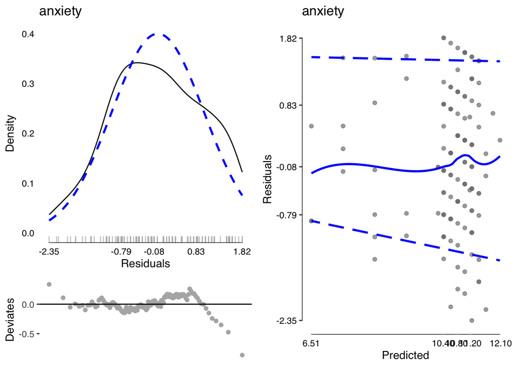

```r
## put your regression diagnostics code including plots using modelDiagnostics() here
md <- modelDiagnostics(m, ev.perc = 0.005)
plot(md, ncol = 2, ask = FALSE)
```

## Linear Regression Summary

Create a summary of your **final** model, after any relevant transformations or extreme values have been addressed, where applicable.

- use `modelTest()` and `APAStyler()` to get a nice result.

Create a graph to help visualize your results using `visreg()`. Note, you may want to adjust the `fig.width` and `fig.height` options to this `R` chunk to make the graph have the ratios you like.

```r
## put your code to summarize the final model using modelTest() here
summary(m)
```

```
##
## Call:
## lm(formula = anxiety ~ sex * conscientiousness, data = db)
##
## Residuals:
##     Min      1Q  Median      3Q     Max
## -7.2428 -2.3816 -0.2428  2.5496  5.5872
##
## Coefficients:
##                             Estimate Std. Error t value Pr(>|t|)
## (Intercept)                  15.8553     3.5102   4.517 1.34e-05 ***
## sexfemale                    -3.3674     3.7115  -0.907   0.3659
## conscientiousness            -1.8684     0.8922  -2.094   0.0381 *
## sexfemale:conscientiousness   1.4534     0.9460   1.536   0.1268
## ---
## Signif. codes:  0 '***' 0.001 '**' 0.01 '*' 0.05 '.' 0.1 ' ' 1
##
## Residual standard error: 3.103 on 137 degrees of freedom
##   (1 observation deleted due to missingness)
## Multiple R-squared:  0.1068, Adjusted R-squared:  0.0872
## F-statistic: 5.458 on 3 and 137 DF,  p-value: 0.00142
```

```r
confint(m) # calculating confidence interval
```

```
##                                   2.5 %     97.5 %
## (Intercept)                   8.9141111 22.7964153
## sexfemale                   -10.7066235  3.9718901
## conscientiousness            -3.6327694 -0.1040727
## sexfemale:conscientiousness  -0.4172786  3.3240883
```

```r
mtest <- modelTest(m)
knitr::kable(APAStyler(mtest)) # clean presentation
```

| Term | Est | Type |
| --- | --- | --- |
| (Intercept) | 15.86*** [ 8.91, 22.80] | Fixed Effects |
| sexfemale | -3.37 [-10.71, 3.97] | Fixed Effects |
| conscientiousness | -1.87* [ -3.63, -0.10] | Fixed Effects |
| sexfemale:conscientiousness | 1.45 [ -0.42, 3.32] | Fixed Effects |
| N (Observations) | 141 | Overall Model |
| logLik DF | 5 | Overall Model |
| logLik | -357.68 | Overall Model |
| AIC | 725.37 | Overall Model |
| BIC | 740.11 | Overall Model |
| F2 | 0.12 | Overall Model |
| R2 | 0.11 | Overall Model |
| Adj R2 | 0.09 | Overall Model |
| sex | f2 = 0.01, p = .366 | Effect Sizes |
| conscientiousness | f2 = 0.03, p = .038 | Effect Sizes |
| sex:conscientiousness | f2 = 0.02, p = .127 | Effect Sizes |

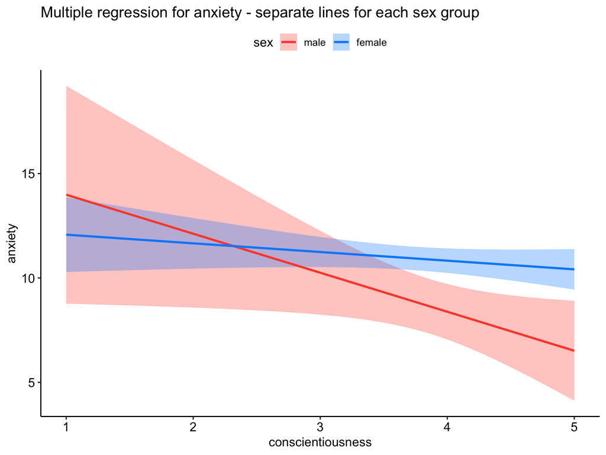

```r
## put your code to visualize your regression model using visreg() here
visreg(m, xvar = "conscientiousness", by = "sex",
       partial = FALSE, rug = FALSE,
       overlay = TRUE, gg = TRUE) +
  theme_pubr() +
  ggtitle("Multiple regression for anxiety - separate lines for each sex group")
```

In the last subheading (Linear Regression Write Up) for GLM1, briefly summarize your analysis steps, assumption checks, any changes performed, and interpret the interaction and regression coefficients, referencing your figure visualizing the result where appropriate. The total length should be about one paragraph and about 150 words.

# 2. Generalized Linear Models 2

1. Conduct one multiple logistic regression predicting high selfesteem “SelfesteemHigh” as created in the GLM2 lecture content **from two predictors of your choosing.**
2. Create a graph of the predicted probabilities of being in the SelfesteemHigh group by each of your two predictors. It should parallel the predicted probability plot in section 4.4 of the GLM2.rmd
3. Report and interpret the odds ratios, 95% confidence intervals for each predictor and present the average marginal effect for each predictor to interpret the results on the probability scale.

## Question 1: GLM High Self Esteem

```r
#create self-esteem from LSE questions
db[, selfesteem:= rowMeans(.SD, na.rm = TRUE),
.SDcols = c("LSE1", "LSE2", "LSE3", "LSE4")]
db[, SelfesteemHigh := as.integer(selfesteem >= 3.75)] #create "SelfesteemHigh" variable

#create extraversion variable (predictor) from BFI_E questions
db [, BFI_E1 := 6- BFI_E1r] # reverse scoring
db[, extraversion := rowMeans(.SD, na.rm = TRUE),
     .SDcols = c("BFI_E1", "BFI_E2")] # creating variable "extraversion"

#create agreeableness variable (predictor) from BFI_A questions
db [, BFI_A2 := 6- BFI_A2r] # reverse scoring
db [, agreeableness := rowMeans(.SD, na.rm = TRUE),
    .SDcols = c("BFI_A1", "BFI_A2")] #creating variable "agreeableness"

mlog <- glm(SelfesteemHigh ~ extraversion + agreeableness,
             data = db, family = binomial())
summary(mlog)
```

```
##
## Call:
## glm(formula = SelfesteemHigh ~ extraversion + agreeableness,
##     family = binomial(), data = db)
##
## Deviance Residuals:
##     Min       1Q   Median       3Q      Max
## -1.8227  -1.0326   0.5002   1.0770   1.9833
##
## Coefficients:
##               Estimate Std. Error z value Pr(>|z|)
## (Intercept)    -3.8995     0.9853  -3.958 7.57e-05 ***
## extraversion    0.6181     0.1756   3.520 0.000432 ***
## agreeableness   0.5649     0.2150   2.627 0.008608 **
## ---
## Signif. codes:  0 '***' 0.001 '**' 0.01 '*' 0.05 '.' 0.1 ' ' 1
##
## (Dispersion parameter for binomial family taken to be 1)
##
##     Null deviance: 195.46  on 140  degrees of freedom
## Residual deviance: 172.75  on 138  degrees of freedom
##   (1 observation deleted due to missingness)
## AIC: 178.75
##
## Number of Fisher Scoring iterations: 4
```

## Question 2: High self esteem probability graph

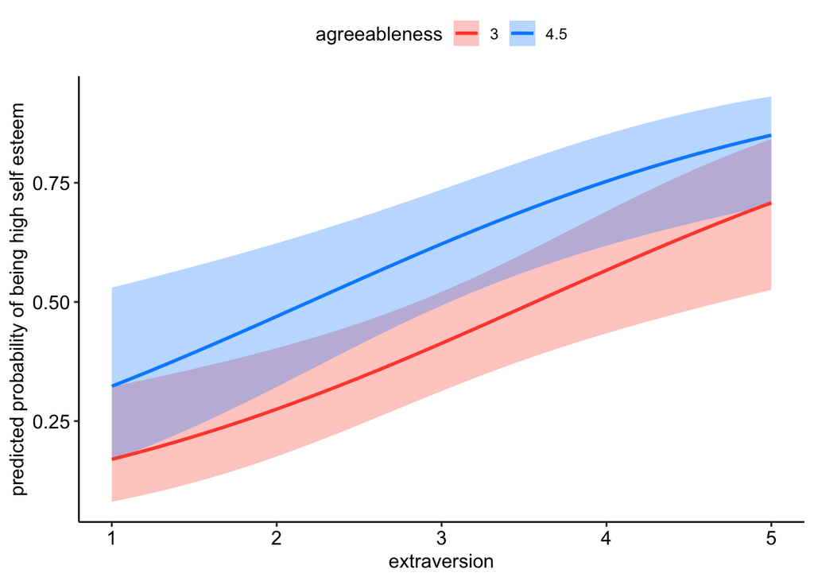

```r
#predicted probability graph for SelfesteemHigh
visreg(mlog, xvar = "extraversion",
       by = "agreeableness", breaks = c(3, 4.5),
       scale = "response", overlay = TRUE,
       partial = FALSE, rug = FALSE, gg = TRUE) +
  ylab("predicted probability of being high self esteem") +
  theme_pubr()
```

## Question 3: Odds Ratio and Marginal Effects

```r
# Calculate Odds Ratio
exp(coef(mlog))
```

```
##   (Intercept)  extraversion agreeableness
##    0.02025243    1.85542483    1.75921801
```

```r
# Calculate Confidence intervals
exp(confint(mlog))
```

```
##                     2.5 %    97.5 %
## (Intercept)   0.002583839 0.1262721
## extraversion  1.330323056 2.6579251
## agreeableness 1.168441202 2.7289755
```

```r
#calculate marginal effect, using h = .01
h <- .01

# making original dataset to interpret with predictors, excluding missing values
originaldata <- db[!is.na(extraversion),
                   .(extraversion, agreeableness)]

# dataset with increased extraversion only
IncreasedExtraversion <- db[!is.na(extraversion),
                   .(extraversion = extraversion + h, agreeableness)]

# dataset with increased agreeableableness only
IncreasedAgreeableness <- db[!is.na(extraversion),
                   .(extraversion, agreeableness = agreeableness + h)]

# calculating predicted probabilities for original, extraversion and agreeableness
originaldata$Prob <- predict(mlog, newdata = originaldata,
                             type = "response")

IncreasedExtraversion$Prob <- predict(mlog, newdata = IncreasedExtraversion,
                             type = "response")

IncreasedAgreeableness$Prob <- predict(mlog, newdata = IncreasedAgreeableness,
                             type = "response")

# calculating the difference in probabilities per unit
ex.diffprob <- (IncreasedExtraversion$Prob - originaldata$Prob) / h
ag.diffprob <- (IncreasedAgreeableness$Prob - originaldata$Prob) / h

# calculating the average marginal effects
mean(ex.diffprob) # extraversion
```

```
## [1] 0.1312677
```

```r
mean(ag.diffprob) # agreeableness
```

```
## [1] 0.1199605
```

## Odds Ratio and Marginal Effect Write up

A multiple logistic regression predicting high self esteem from extraversion and agreeableness showed that for each additional unit of extraversion, participants have 1.86 times the odds of having high self-esteem [95% CI 1.33 - 2.66], p < .001. For each additional unit of agreeableness, participants have 1.76 times the odds of having high self-esteem [95% CI 1.17 - 2.73], p < .01. When holding agreeableness constant, increasing extraversion by one unit on average is predicted to result in 0.13 change (increase) in the probability of having high self-esteem. Alternatively, when holding extraversion constant, increasing agreeableness by one unit on average is predicted to results in 0.12 change (increase) in the probability of having high self-esteem. A graph of predicted probability of the model grouped by agreeableness visually had similar slopes.